# Germination drivers preliminary analysis

## Basic calculations

### Viable seed calculation per petri dish

```r
read.csv("data/raw_data.csv", sep = ",") %>%
  convert_as_factor(species, code, treatment, temp) %>%
  dplyr::select (species, code, treatment, petri, initial, empty, fungus) %>%
  group_by (species, code, treatment, petri) %>%
  mutate (viable = initial -(empty + fungus)) %>%
  dplyr::select (species, code, treatment, petri, viable) -> viables_petri
unique(viables_petri$species)
```

```
##  [1] Agrostis tileni               Androsace villosa
##  [3] Anthyllis vulneraria          Arenaria erinacea
##  [5] Armeria cantabrica            Armeria duriaei
##  [7] Avenella flexuosa             Carex sempervirens
##  [9] Cerastium ramossissimum       Conopodium majus
## [11] Dianthus langeanus            Erigeron alpinus
## [13] Euphrasia salisburgensis      Festuca glacialis
## [15] Festuca rubra                 Festuca summilusitana
## [17] Galium pyrenaicum             Gentiana verna
## [19] Gentianella campestris        Gypsophila repens
## [21] Helianthemum canum            Helianthemum urrielense
## [23] Helictochloa marginata        Jasione cavanillesii
## [25] Jasione laevis                Jurinea humilis
## [27] Kobresia myosuroides          Koeleria vallesiana
## [29] Linaria alpina                Luzula caespitosa
## [31] Minuartia CF                  Minuartia recurva
## [33] Minuartia verna               Neoschischkinia truncatula
## [35] Pedicularis pyrenaica         Phalacrocarpum oppositifolium
## [37] Phyteuma hemisphaericum       Plantago alpina
## [39] Plantago holosteum            Salix breviserrata
## [41] Saxifraga conifera            Saxifraga oppositifolia
## [43] Saxifraga paniculata          Scilla verna
## [45] Sedum album                   Sedum anglicum
## [47] Sedum atratum                 Sedum brevifolium
## [49] Sempervivum arachnoideum      Sempervivum vicentei
## [51] Silene acaulis                Silene ciliata
## [53] Solidago virgaurea            Spergula morisonii
## [55] Teesdalia conferta            Thymus praecox
## [57] Veronica nummularia
## 57 Levels: Agrostis tileni Androsace villosa ... Veronica nummularia
```

```r
head(viables_petri)
```

```
## # A tibble: 6 x 5
## # Groups:   species, code, treatment, petri [6]
##   species         code      treatment         petri viable
##   <fct>           <fct>     <fct>             <int>  <int>
## 1 Agrostis tileni 090822-01 A_alternate_light     1     24
## 2 Agrostis tileni 090822-01 A_alternate_light     2     24
## 3 Agrostis tileni 090822-01 A_alternate_light     3     24
## 4 Agrostis tileni 090822-01 A_alternate_light     4     24
## 5 Agrostis tileni 090822-01 B_alternate_dark      1     24
## 6 Agrostis tileni 090822-01 B_alternate_dark      2     24
```

### Viables calculation per community

```r
read.csv("data/raw_data.csv", sep = ",") %>%
    convert_as_factor(species, code, treatment, temp) %>%
    dplyr::select (species, code, treatment, petri, initial, empty, fungus) %>%
    group_by (species, code, treatment, petri) %>%
    mutate (viable = initial -(empty + fungus)) %>%
    dplyr::select (species, code, treatment, petri, viable)%>%
    merge(species)%>%
  filter (!species == "Euphrasia salisburgensis")%>%
  filter (!species == "Gentiana verna")%>%
  filter (!species == "Gentianela campestris")%>%
  filter (!species == "Kobresia myosuroides")%>%
  filter (!species == "Salix breviserrata")%>%
  filter (!species == "Sedum album")%>%
  filter (!species == "Sedum atratum")%>%
  filter (!species == "Solidago virgaurea")%>%
    group_by (community, treatment)%>%
    summarise(viable= sum(viable))-> viables_community
viables_community
```

```
## # A tibble: 8 x 3
## # Groups:   community [2]
##   community     treatment         viable
##   <fct>         <fct>              <int>
## 1 Mediterranean A_alternate_light   1857
## 2 Mediterranean B_alternate_dark    1865
## 3 Mediterranean C_alternate_WP      1793
## 4 Mediterranean D_constant_light    1860
## 5 Temperate     A_alternate_light   2255
## 6 Temperate     B_alternate_dark    2302
## 7 Temperate     C_alternate_WP      2164
## 8 Temperate     D_constant_light    2261
```

### Viables calculation per species and treatment

```r
read.csv("data/raw_data.csv", sep = ",") %>%
    convert_as_factor(species, code, treatment, temp) %>%
    dplyr::select (species, code, treatment, petri, initial, empty, fungus) %>%
    group_by (species, code, treatment, petri) %>%
    mutate (viable = initial -(empty + fungus)) %>%
    dplyr::select (species, code, treatment, petri, viable)%>%
    group_by (species,code, treatment)%>%
    summarise(viable= sum(viable))-> viables_sp
unique(viables_sp$species)
```

```
##  [1] Agrostis tileni               Androsace villosa
##  [3] Anthyllis vulneraria          Arenaria erinacea
##  [5] Armeria cantabrica            Armeria duriaei
##  [7] Avenella flexuosa             Carex sempervirens
##  [9] Cerastium ramossissimum       Conopodium majus
## [11] Dianthus langeanus            Erigeron alpinus
## [13] Euphrasia salisburgensis      Festuca glacialis
## [15] Festuca rubra                 Festuca summilusitana
## [17] Galium pyrenaicum             Gentiana verna
## [19] Gentianella campestris        Gypsophila repens
## [21] Helianthemum canum            Helianthemum urrielense
## [23] Helictochloa marginata        Jasione cavanillesii
## [25] Jasione laevis                Jurinea humilis
## [27] Kobresia myosuroides          Koeleria vallesiana
## [29] Linaria alpina                Luzula caespitosa
## [31] Minuartia CF                  Minuartia recurva
## [33] Minuartia verna               Neoschischkinia truncatula
## [35] Pedicularis pyrenaica         Phalacrocarpum oppositifolium
## [37] Phyteuma hemisphaericum       Plantago alpina
## [39] Plantago holosteum            Salix breviserrata
## [41] Saxifraga conifera            Saxifraga oppositifolia
## [43] Saxifraga paniculata          Scilla verna
## [45] Sedum album                   Sedum anglicum
## [47] Sedum atratum                 Sedum brevifolium
## [49] Sempervivum arachnoideum      Sempervivum vicentei
## [51] Silene acaulis                Silene ciliata
## [53] Solidago virgaurea            Spergula morisonii
## [55] Teesdalia conferta            Thymus praecox
## [57] Veronica nummularia
## 57 Levels: Agrostis tileni Androsace villosa ... Veronica nummularia
```

```r
head(viables_sp)
```

```
## # A tibble: 6 x 4
## # Groups:   species, code [2]
##   species           code      treatment         viable
##   <fct>             <fct>     <fct>              <int>
## 1 Agrostis tileni   090822-01 A_alternate_light     96
## 2 Agrostis tileni   090822-01 B_alternate_dark      95
## 3 Agrostis tileni   090822-01 C_alternate_WP        92
## 4 Agrostis tileni   090822-01 D_constant_light      99
## 5 Androsace villosa 310822-01 A_alternate_light     99
## 6 Androsace villosa 310822-01 B_alternate_dark      97
```

### Germination during cold stratification period

```r
read.csv("data/raw_data.csv", sep = ",") %>%
  convert_as_factor(species, code, treatment, temp) %>%
  merge(viables_petri) %>%
  dplyr::select (species, code, petri, viable, initial, cold_strat) %>% ##
  na.omit() %>% #remove alternate dark treatment rows
  group_by (species, code,petri) %>%
  dplyr::summarize(finalgerm = sum(cold_strat),
            viable = sum(viable)) %>%
  mutate (finalgerm = replace_na(finalgerm , 0)) %>% # salix and solidago have some petridish with all fungus
  mutate (treatment = "E_cold_stratification") %>%
  mutate(treatment = as.factor(treatment))-> cold_strat
unique(cold_strat$species)
```

```
##  [1] Agrostis tileni               Androsace villosa
##  [3] Anthyllis vulneraria          Arenaria erinacea
##  [5] Armeria cantabrica            Armeria duriaei
##  [7] Avenella flexuosa             Carex sempervirens
##  [9] Cerastium ramossissimum       Conopodium majus
## [11] Dianthus langeanus            Erigeron alpinus
## [13] Euphrasia salisburgensis      Festuca glacialis
## [15] Festuca rubra                 Festuca summilusitana
## [17] Galium pyrenaicum             Gentiana verna
## [19] Gentianella campestris        Gypsophila repens
## [21] Helianthemum canum            Helianthemum urrielense
## [23] Helictochloa marginata        Jasione cavanillesii
## [25] Jasione laevis                Jurinea humilis
## [27] Kobresia myosuroides          Koeleria vallesiana
## [29] Linaria alpina                Luzula caespitosa
## [31] Minuartia CF                  Minuartia recurva
## [33] Minuartia verna               Neoschischkinia truncatula
## [35] Pedicularis pyrenaica         Phalacrocarpum oppositifolium
## [37] Phyteuma hemisphaericum       Plantago alpina
## [39] Plantago holosteum            Salix breviserrata
## [41] Saxifraga conifera            Saxifraga oppositifolia
## [43] Saxifraga paniculata          Scilla verna
## [45] Sedum album                   Sedum anglicum
## [47] Sedum atratum                 Sedum brevifolium
## [49] Sempervivum arachnoideum      Sempervivum vicentei
## [51] Silene acaulis                Silene ciliata
## [53] Solidago virgaurea            Spergula morisonii
## [55] Teesdalia conferta            Thymus praecox
## [57] Veronica nummularia
## 57 Levels: Agrostis tileni Androsace villosa ... Veronica nummularia
```

```r
head(cold_strat)
```

```
## # A tibble: 6 x 6
## # Groups:   species, code [2]
##   species           code      petri finalgerm viable treatment
##   <fct>             <fct>     <int>     <int>  <int> <fct>
## 1 Agrostis tileni   090822-01     1         1     72 E_cold_stratification
## 2 Agrostis tileni   090822-01     2         0     73 E_cold_stratification
## 3 Agrostis tileni   090822-01     3         3     70 E_cold_stratification
## 4 Agrostis tileni   090822-01     4         0     72 E_cold_stratification
## 5 Androsace villosa 310822-01     1         1     73 E_cold_stratification
## 6 Androsace villosa 310822-01     2         0     74 E_cold_stratification
```

#### Visualization of germination during cold stratification pre-treatment with binomial errors

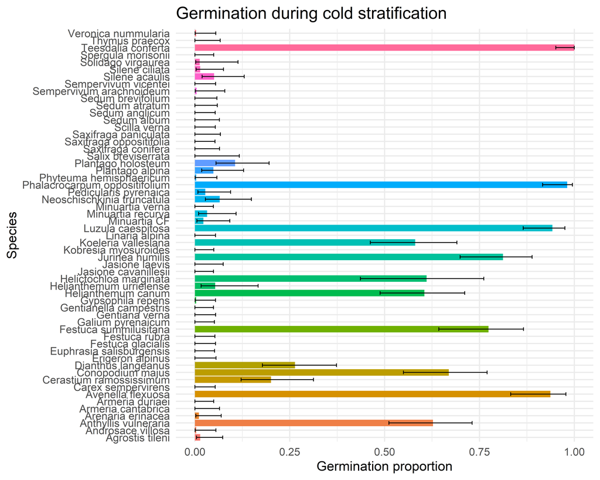

Germination during cold stratification

### Separate datsets per community with germination during cold stratification period

```r
cold_strat %>%
  group_by(species, code, treatment)%>%
  dplyr::summarize(finalgerm = sum(finalgerm),
                   viable = sum(viable))%>%
  merge(species)%>%
  filter(community=="Mediterranean")%>%
  dplyr::select(code, species, treatment, viable, finalgerm)->cold_strat_M; cold_strat_M
```

```
##         code                       species             treatment viable
## 1  090822-01               Agrostis tileni E_cold_stratification    287
## 2  040822-02               Armeria duriaei E_cold_stratification    295
## 3  110822-03             Avenella flexuosa E_cold_stratification    146
## 4  280721-02       Cerastium ramossissimum E_cold_stratification    264
## 5  250821-04              Conopodium majus E_cold_stratification    261
## 6  040822-01            Dianthus langeanus E_cold_stratification    299
## 7  250821-02         Festuca summilusitana E_cold_stratification    203
## 8  040822-10        Helictochloa marginata E_cold_stratification    123
## 9  040822-08                Jasione laevis E_cold_stratification    191
## 10 110822-01               Jurinea humilis E_cold_stratification    126
## 11 040822-04             Luzula caespitosa E_cold_stratification    294
## 12 110821-07             Minuartia recurva E_cold_stratification    251
## 13 240821-07    Neoschischkinia truncatula E_cold_stratification    275
## 14 040822-05 Phalacrocarpum oppositifolium E_cold_stratification    206
```

[output cut: 35 more lines]

```r
cold_strat %>%
  group_by(species, code, treatment)%>%
  dplyr::summarize(finalgerm = sum(finalgerm),
                   viable = sum(viable))%>%
  merge(species)%>%
  filter(community=="Temperate")%>%
  dplyr::select(code, species, treatment, viable, finalgerm)->cold_strat_T;cold_strat_T
```

```
##         code                  species             treatment viable finalgerm
## 1  310822-01        Androsace villosa E_cold_stratification    295         1
## 2  120722-02     Anthyllis vulneraria E_cold_stratification    282       177
## 3  300821-08        Arenaria erinacea E_cold_stratification    280         3
## 4  230822-01       Armeria cantabrica E_cold_stratification    222         0
## 5  190822-08       Carex sempervirens E_cold_stratification    271         0
## 6  190822-12         Erigeron alpinus E_cold_stratification    196         0
## 7  011021-01 Euphrasia salisburgensis E_cold_stratification    281         0
## 8  230822-04        Festuca glacialis E_cold_stratification    270         0
## 9  310821-02            Festuca rubra E_cold_stratification    138         0
## 10 310822-03        Galium pyrenaicum E_cold_stratification    283         0
## 11 130921-06           Gentiana verna E_cold_stratification    267         0
## 12 300921-03   Gentianella campestris E_cold_stratification    298         0
## 13 190822-10        Gypsophila repens E_cold_stratification    300         1
## 14 310821-05       Helianthemum canum E_cold_stratification    281       170
```

[output cut: 20 more lines]

### Final germination percentage per treatment discounting cold stratification germ in darkness treatment

```r
read.csv("data/raw_data.csv", sep = ",") %>%
  convert_as_factor(species, code, treatment, temp) %>%
  dplyr::select (species, code, treatment, petri, initial, D7, D14, D21, D28, D35, D42) %>%
  gather ("scores", "germ", D7:D42) %>%
  mutate (germ = replace_na(germ, 0)) %>%
  group_by (species, code, treatment, petri)%>%
  dplyr::summarize (finalgerm = sum(germ)) %>% #
  dplyr::select(species, code, treatment, petri, finalgerm)%>%
  merge(viables_petri, by= c("species", "code", "treatment", "petri")) %>%
  rbind(cold_strat)%>%
  group_by (species, code, treatment) %>%
  dplyr::summarize(finalgerm = sum (finalgerm)) %>%
  spread(treatment, finalgerm)%>%
  mutate (B_alternate_dark = B_alternate_dark - E_cold_stratification)  %>% # substract cold stratification
  mutate (B_alternate_dark = ifelse(B_alternate_dark < 0, 0, B_alternate_dark)) %>% # convert negative values to 0 germination
  gather ("treatment", "finalgerm", A_alternate_light:E_cold_stratification) %>%
  filter(!treatment=="E_cold_stratification")%>%
  merge(viables_sp, by= c("code", "species", "treatment"))-> finalgerm;finalgerm
```

```
##          code                       species         treatment finalgerm viable
## 1   011021-01      Euphrasia salisburgensis A_alternate_light         0     87
## 2   011021-01      Euphrasia salisburgensis  B_alternate_dark         0     95
## 3   011021-01      Euphrasia salisburgensis    C_alternate_WP         0     95
## 4   011021-01      Euphrasia salisburgensis  D_constant_light         0     99
## 5   040822-01            Dianthus langeanus A_alternate_light        75    100
## 6   040822-01            Dianthus langeanus  B_alternate_dark        17    100
## 7   040822-01            Dianthus langeanus    C_alternate_WP        55     99
## 8   040822-01            Dianthus langeanus  D_constant_light        73    100
## 9   040822-02               Armeria duriaei A_alternate_light         7     98
## 10  040822-02               Armeria duriaei  B_alternate_dark         0     97
## 11  040822-02               Armeria duriaei    C_alternate_WP         0     99
## 12  040822-02               Armeria duriaei  D_constant_light        59     98
## 13  040822-04             Luzula caespitosa A_alternate_light         1    100
## 14  040822-04             Luzula caespitosa  B_alternate_dark         0     98
```

[output cut: 218 more lines]

```r
str(finalgerm)
```

```
## 'data.frame':    232 obs. of  5 variables:
##  $ code     : Factor w/ 58 levels "011021-01","040822-01",..: 1 1 1 1 2 2 2 2 3 3 ...
##  $ species  : Factor w/ 57 levels "Agrostis tileni",..: 13 13 13 13 11 11 11 11 6 6 ...
##  $ treatment: chr  "A_alternate_light" "B_alternate_dark" "C_alternate_WP" "D_constant_light" ...
##  $ finalgerm: num  0 0 0 0 75 17 55 73 7 0 ...
##  $ viable   : int  87 95 95 99 100 100 99 100 98 97 ...
```

```r
head(finalgerm)
```

```
##        code                  species         treatment finalgerm viable
## 1 011021-01 Euphrasia salisburgensis A_alternate_light         0     87
## 2 011021-01 Euphrasia salisburgensis  B_alternate_dark         0     95
## 3 011021-01 Euphrasia salisburgensis    C_alternate_WP         0     95
## 4 011021-01 Euphrasia salisburgensis  D_constant_light         0     99
## 5 040822-01       Dianthus langeanus A_alternate_light        75    100
## 6 040822-01       Dianthus langeanus  B_alternate_dark        17    100
```

### Graph comparing final germiantion between treatment at community level

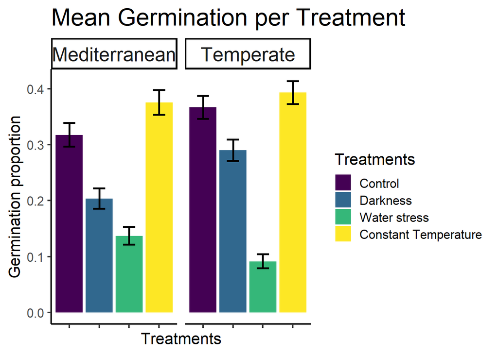

#### Cumulative germination graph for each treatment at community level

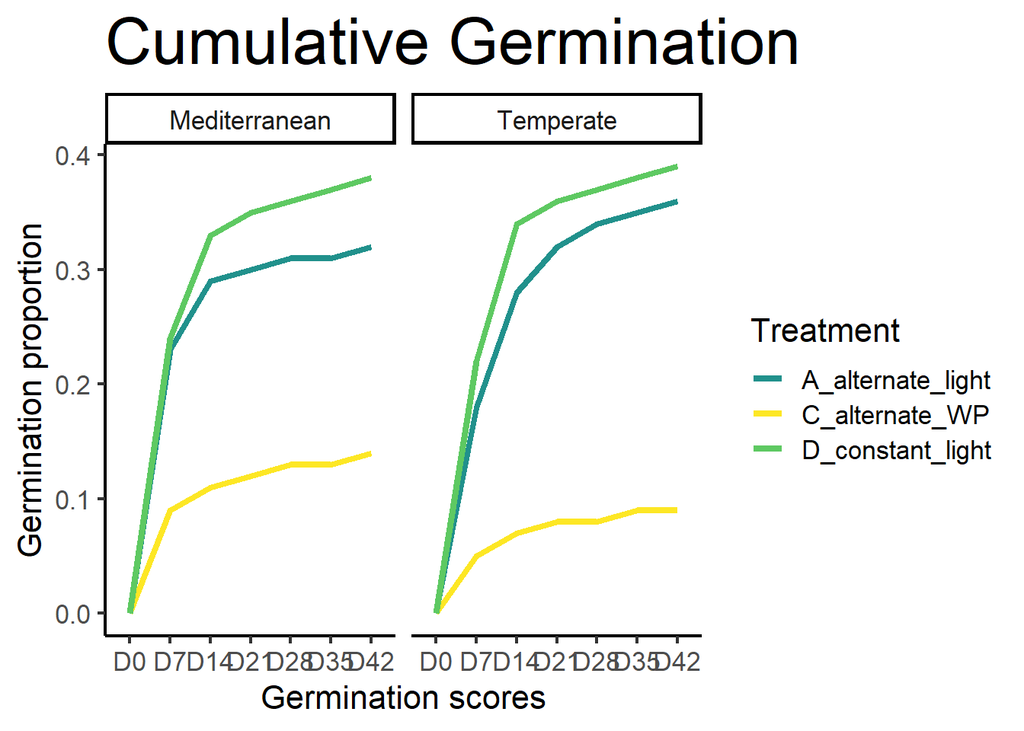

# Species preferences

Species preferences calculated from ibuttons data and inventories the original scripts and data in Omaña80 and Picos Github repository (respectively) script name: indices and glms climatic indices used:  
FROM ibuttons data: in picos from 02/10/2018 to 07/08/2019; in villabandin from 12/07/2021 to 29/05/2022  
FDD: sum of degrees (daily mean) when daily Tmean is below 0 ºC (in absolute values)  
GDD: sum of degrees (daily mean) when daily Tmean is above 5 ºC  
Snowdays = sum of days with snow cover, calculated as days when Tmax <0.5 and Tmin > -0.5 ºC  
These variables (altogether with bio1, bio2 and bio7) calculated mean x day, then month and finally year (whole datset)

From inventory data: 80 plots per each community, at each plot species coverage estimated in % To calculate species preferences several filters applied: # consider only plots where each species has at least 10% coverage # climatic variables weighted per coverage